# Visualization

## Introduction

WeRateDogs is a Twitter account, started in Nov., 2015, which rates people's dogs with a humorous comment about the dog. Dogs are rated on a scale of one to ten, but are invariably given ratings in excess of the maximum, such as "13/10".

The goal of this project is wrangling tweet archive of Twitter user @dog_rates to create interesting and trustworthy analyses and visualizations.

This report communicates the insights I gained via visualization. I explored the data by

1. Ask questions
2. Answer quesions using data

## As time goes, does WeRateDogs trend upward or downward?

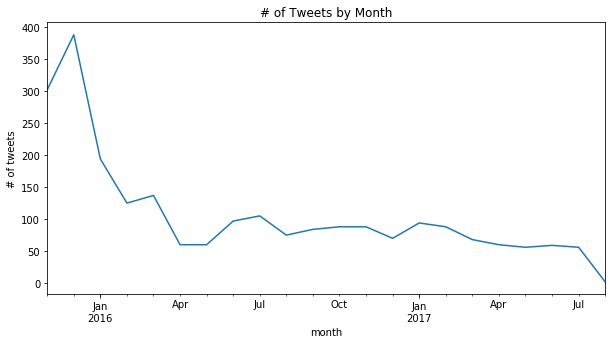

```python
df.groupby(df.timestamp.dt.to_period('M')).agg('count')['tweet_id'].plot(kind = 'line', figsize = [10, 5], title = '# of Tweets by Month')
plt.xlabel('month')
plt.ylabel('# of tweets');
```

#### We can see that WeRateDogs trends downward as time goes

## What time in a day WeRateDogs is most active ?

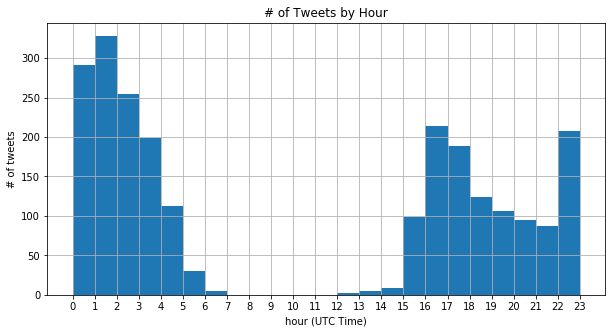

```python
df['hour'] = df.timestamp.dt.hour
hours_bin = np.arange(0, 24, 1)
df.hour.hist(figsize = [10, 5], bins = hours_bin)
plt.xticks(hours_bin);
plt.xlabel('hour (UTC Time)')
plt.ylabel('# of tweets')
plt.title('# of Tweets by Hour');
```

#### The plot shows that users are most active between 00:00 - 03:00 in UTC (19:00 - 22:00 in EST), followed by 3:00 - 4:00, 16:00 - 18:00, 22:00 - 23:00 UTC (22:00 - 23:00, 11:00 - 13:00, 17:00 - 18:00 in EST)</blue>

## Which apps/clients users use the most to post tweets?

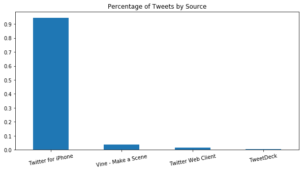

```python
df.source.value_counts(normalize = True).plot(kind = 'bar', figsize = [10, 5], title = 'Percentage of Tweets by Source', yticks = np.arange(0, 1, 0.1), rot = 10);
```

## Do users tend to rate high or low?

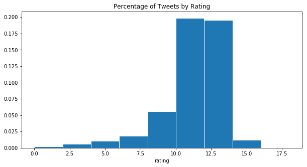

```python
# Distribution of tweets across ratings
bins_rating = np.arange(0, df.rating.max() + 2, 2)
df[~df.rating.isnull()].rating.hist(figsize = [10, 5], bins = bins_rating, density = 1, grid = False, edgecolor='white')
plt.title('Percentage of Tweets by Rating');
plt.xlabel('rating');
```

```python
# For the following analysis, only 'General Tweets' are takein into account (See definition of 'General Tweets' by Twitter - https://help.twitter.com/en/using-twitter/types-of-tweets)
df_tweets_general = df[df.retweeted_status_id.isnull()]
```

## Any correlation between retweet_count and favoriate_count ?

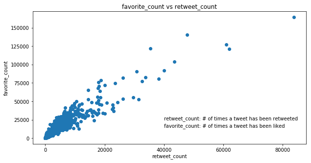

```python
plt.figure(figsize = [10, 5])
plt.scatter(x = df_tweets_general.retweet_count, y = df_tweets_general.favorite_count)
plt.title('favorite_count vs retweet_count')
plt.xlabel('retweet_count')
plt.ylabel('favorite_count')
plt.text(40000, 25000, 'retweet_count: # of times a tweet has been retweeted')
plt.text(40000, 15000, 'favorite_count: # of times a tweet has been liked');
```

#### It makes perfect sense that the more frequent a tweet is retweeted, the more likes it gets

## What top 10 popular dog names?

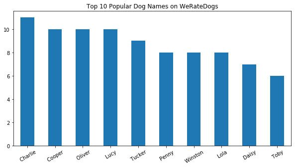

```python
top_names.plot(kind = 'bar', figsize = [10, 5], rot = 30, title = 'Top 10 Popular Dog Names on WeRateDogs');
```

## What are top 10 popular dog breeds on WeRateDogs ?

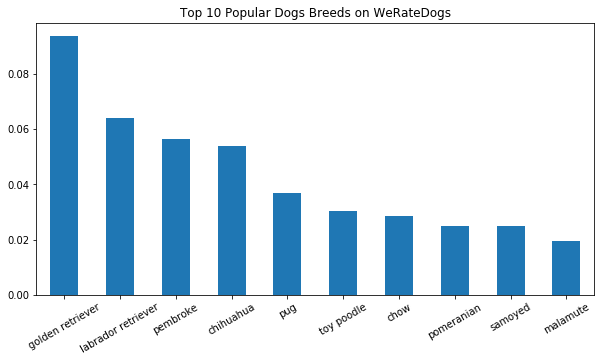

```python
top_popular.plot(kind = 'bar', figsize = [10, 5], rot = 30, title = 'Top 10 Popular Dogs Breeds on WeRateDogs');
```

## What are top 10 rated dog breeds on WeRateDogs ?

```python
mean_per_breed = df_tweets_general.groupby('breed')[['rating', 'favorite_count']].mean()
```

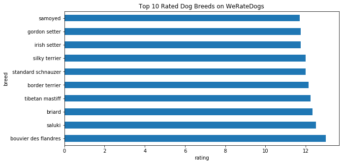

```python
top_rated.plot(kind = 'barh', figsize = [10, 5])
plt.xlabel('rating')
plt.title('Top 10 Rated Dog Breeds on WeRateDogs');
```

#### Note: The breed which gets the highest rating (bouvier des flandres) actually has only one rating

## What are top 10 liked dog breeds on WeRateDogs ?

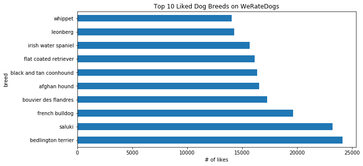

```python
top_liked.plot(kind = 'barh', figsize = [10, 5])
plt.xlabel('# of likes')
plt.title('Top 10 Liked Dog Breeds on WeRateDogs');
```

```python
top_popular_set = set(top_popular.index.tolist())
top_liked_set = set(top_liked.index.tolist())
top_rated_set = set(top_rated.index.tolist())
```

#### There is no overlapping between 'top 10 popular' and 'top 10 liked'; only one breed (*samoyed*) shows up in both 'top 10 popular' and 'top 10 rated', two breeds (*bouvier des flandres* and *saluki*) fall into both 'top 10 rated' and 'top 10 liked'

## What is the most retweeted tweet ?

Here it is: https://twitter.com/dog_rates/status/744234799360020481

It's funny to see the dog stop swimming when it realizes that it really doesn't need to swim ... A big smile on my face ...

## Insights

1. As time goes, WeRateDogs trends downward
2. Users are most active between 00:00 - 03:00 in UTC (19:00 - 22:00 in EST), followed by 3:00 - 4:00, 16:00 - 18:00, 22:00 - 23:00 UTC (22:00 - 23:00 , 11:00 - 13:00, 17:00 - 18:00 in EST)
3. Twitter for iPhone is the most popular app/client to post tweets
4. The more frequent a tweet is retweeted, the more likes it gets. In other words, # of times a tweet is retweeted is strongly positive correlated with # of likes it gets
5. The most popular dog breed is *golden retriever*
6. The breed which get the highest rating is *bouvier des flandres* - it actually has only ONE rating
7. The breed which gets the most likes is *bedlington terrier*
8. There is little overlapping between 'top 10 popular breeds', 'top 10 rated breeds' and 'top 10 liked breeds'. From a user's perspective, if I like/retweet a tweet highly depends on the quality of the content: if images/text tells a good story, sends an important message and etc ... it really doesn't depend on the dog's breed ...

## Limitations

The analysis on *rating* and *breed* is based on a small dataset with errorous data, and hence the insights 5 - 8 may be biased.

1. Out of total 2356 tweets from 11/15/2015 to 08/01/2017, 2175 are non-retweet tweets; out of 2175 non-retweet tweets, 1686 has preditions, ~ 1552 has names, ~ 2154 has ratings
2. names and ratings may not be 100% extracted correctly
3. Image classification system used for this study, in some cases, can't detect dogs in images. Even if it can detect dog and predict its breed, the predition may be wrong.
4. The image-predictions.tsv only includes top 3 predictions for images (a tweet may have multiple images) with the highest top 5 prediction - the truly right prediction may be exluced.